# Part II - (Ford GoBike System Dataset Exploration)

## by (Salvation Peter)

## Investigation Overview

This data set includes information about individual rides made in a bike-sharing system covering the greater San Francisco Bay area. I would be exploring this data, to understand it better as well as answer basic questions such as

- When are most trips taken in terms of time of day, day of the week, or month of the year? and
- Does the above depend on if a user is a subscriber or customer?

## Dataset Overview

> The Ford GoBike System data consists of 183412 records with a total of 16 columns; 3 datetime columns, 4 float columns, 1 integer column and 8 object columns. Each of this columns give an information regarding each ride such as which bike was used, where was the starting point and ending point, how long did the ride take, etc.

> The columns include 'duration_sec', 'start_time', 'end_time', 'start_station_id', 'start_station_name', 'start_station_latitude', 'start_station_longitude', 'end_station_id', 'end_station_name', 'end_station_latitude', 'end_station_longitude', 'bike_id', 'user_type', 'member_birth_year', 'member_gender', 'bike_share_for_all_trip'.

> Some of these columns were read in with the wrong data type which were changed before the exploration. Also a new column was added pointing to the particular day in the week for each start_time.

## Part 1

> Let's begin by looking at the duration_sec, the user_type, member_gender and Day columns individually

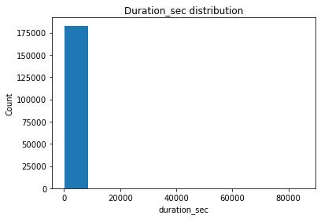

Here we notice that most ride durations fall way less than 20,000s but there are few outliers reaching upto 80,000s

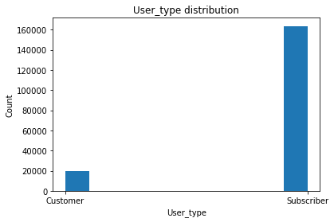

We notice here that many riders are Subscribers than Customers

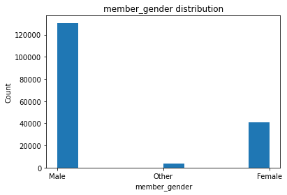

We observe here that there more male riders followed by Females then Others.

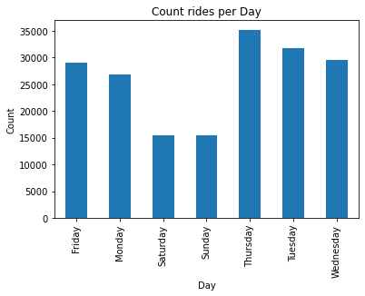

It is evident that there are more rides on Thursday than any other day of the week

## Part 2

> How are these distributions related to each other? Can they shed more light on the dataset?

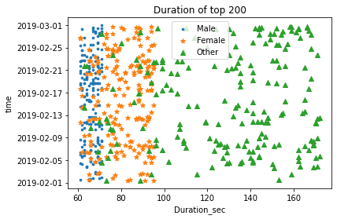

Top 200 males have their mean ride duration less than 80s, females about 100s and others take up to 160s

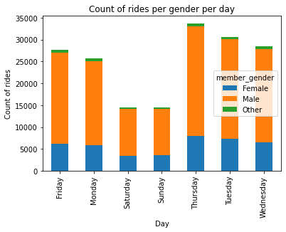

Males have more rides across the days followed by Females

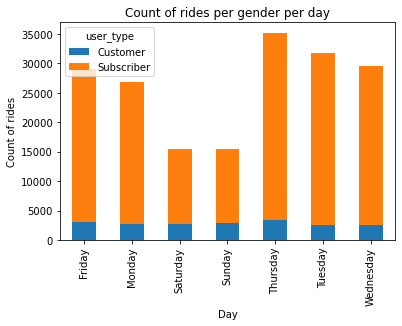

Subscribers have more rides across the days

## Part 3

> Here we look at a more detailed version of the visualizations above. This would really give answers to the questions asked earlier.
- What is the average duration of rides per day per gender class?

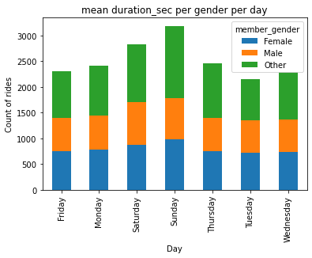

Here we see that Sunday records the day with the highest average with the 'Other' gender class topping the average duration among the gender classes. This implies that people are more relaxed on their rides on Sunda than other days.

- What is the average duration of rides per day per user type?

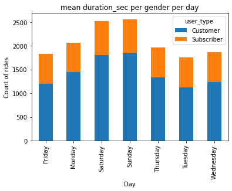

It is evident from the last chart that the user type customer has the highest mean duration of rides across the days. This gives an understanding that Subscribers either try to maximize the hours the subscribed to and hence ride fast or short distances compared to the customers. This though is not a reliable conclusion as the data is not able to prove this.

- The last major question we need to look at is What is the mean duration of rides per user type per gender class irrespective of the day?

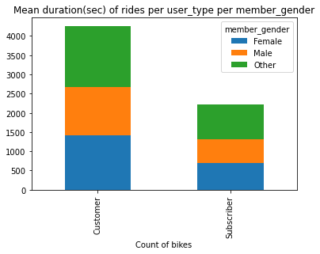

This conclusion is a response to the questions posed at the begining of this presentation, most rides were taken on Thursday even though the mean duration on this day is low.

Sunday followed closely by Saturday ranks top days with the highest mean duration of rides. This could imply that the riders are more relaxed on their rides on Saturday and Sunday than on Thursday and other days.

In the visualizations, it is obvious that the customers had a higher mean duration than the subscribers which is also quite understandable in that subscribers may be limited in how long they can have a ride despite their being relaxed or not.